# Final Project Workflow

Shira Buzaglo and Yotam Nir

23.7.2021

### Loading packages and data preparation

Workflow remarks:

1. Before importing the prices data, an excel edit was required – `text to columns` with `|` as a separator.
2. The .csv files were renamed externally for convenience.

```r
if (!require("pacman")) install.packages("pacman")
pacman::p_load(
  tidyverse,
  broom,         # for tidying displays
  kableExtra,    # for table design
  doBy,          # for group-wise data adjustments
  reshape2,      # for data adjustments
  data.table,    # for data adjustments
  fixest,        # for convenient estimation of fixed effects and IV regressions and clustering
  matsindf,      # for "group_by_everything_except" function
  BLPestimatoR,  # for BLP estimation
  Rcpp,          # required for BLPestimatoR
  fastDummies,   # for conveniently turning categorical variables into dummies
  nleqslv,       # for solving non-linear FOCs
  ddpcr          # used here for the 'quiet' function
)

# Function for table formatting (credit to Alon Rashty)
kable_format <- function(x, digits = 1, caption = NULL, position = "center") {
  kbl(x = x, digits = digits, caption = caption) %>%
  row_spec(row = 0,bold = TRUE) %>%
  kable_classic_2(lightable_options = c("bordered", "hover"), full_width = F,
                  html_font = "Cambria",position = position
                  )
}


# Downloaded on 21.07.2021.
prices <- read.csv("Prices.csv") %>%
  as_tibble() %>%
  filter(
    shnat_yitzur > 2016,   # no cars produced before 2017 in quantities data
    sug_degem == "P"       # interested only in private and not commercial vehicles
  ) %>%
  select(-sug_degem)       # no longer informative

# Downloaded on 21.06.2021
quantities <- read.csv("Monthly 2018-2021.csv") %>%
  as_tibble() %>%
  filter(Sug.Degem == "P") %>%
  select(-Sug.Degem)

# Fixing a small spelling mistake
quantities$Country.of.Origin[which(quantities$Country.of.Origin == "Soutch Korea")] <- "South Korea"
```

Here we join quantity and price data by model number, manufacturing year, and producing country:

```r
cars <- full_join(
  quantities, prices,
  by = c(
    "Degem.Cd" = "degem_cd",
    "Shnat.Yitzur" = "shnat_yitzur",
    "Tozeret.Cd" = "tozeret_cd"
  )
) %>%
  rename(Make.ENG = ן..Make.ENG) %>%
  filter(!is.na(kinuy_mishari), !is.na(Make.ENG)) %>%
  select(-Degem.Nm, -degem_nm, -Kinuy.Mishari, -kinuy_mishari)
```

Next, we join together some incorrectly separated rows (exact same model, same production line, same production year), and at the same time also aggregate model sales by quarter (currently by month):

```r
cars <- cars %>%
  mutate(
    Date = as.Date(Date,"%m/%d/%Y"),
    month = as.numeric((substr(Date,6,7))),
    year = as.numeric(substr(Date,1,4)),
    quarter =  case_when(month %in% c(1,2,3) ~ 1,
                        month %in% c(4,5,6) ~ 2,
                        month %in% c(7,8,9) ~ 3,
                        month %in% c(10,11,12) ~ 4)
  ) %>%
  group_by_everything_except("Car.num", "Car.num.prec", "month", "Date", "Sgira.Date") %>%
  summarise(Car.num = sum(Car.num),
            Car.num.prec = sum(Car.num.prec)) %>%
  ungroup() %>%
  filter(!is.na(quarter))
```

Here we add the exchange rate data, retrieved from [BOI](https://www.boi.org.il/he/Markets/ExchangeRates/Pages/Default.aspx). Since data is daily we create an average yearly rate, in line with the frequency of our price variable. We also adjust prices for inflation (base = 2010) and divide by 1000 for easier interpretation of the coefficients.

```r
# Read and arrange exchange rates data
ExchangeRates <- read.csv("ExchangeRates.csv") %>%
  rename(date = ן..date) %>%
  mutate(
    date = as.Date(date,"%d/%m/%Y"),
    year = as.factor(substr(date,1,4))
  ) %>%
  select(-date) %>%
  group_by(year) %>%      # Taking the yearly average exchange rate:
  summarise(
    USD = mean(USD),
    Yen=mean(Yen),
    Euro = mean(Euro),
    Pound = mean(Pound)
  ) %>%
  ungroup()

# Reshape from wide to long before merging
long <- melt(
  setDT(ExchangeRates),
  id.vars = c("year"),
  variable.name = "currency"
) %>%
  rename(ExchangeRate = value)

# Creating a currency variable to merge on in the cars data
cars <- cars %>% mutate(
  currency = case_when(
    Country.of.Origin %in% c("Thailand", "Mexico", "United States", "India",
                             "Morocco", "China", "South Korea", "Canada",
                             "South Africa") ~ "USD",
    Country.of.Origin %in% c("Portugal", "Germany", "Slovakia", "France",
                             "Italy", "Spain", "Hungary", "Turkey",
                             "Poland", "Czech Republic", "Romania", "Sweden",
                             "Belgium", "Netherlands", "Austria", "Slovenia",
                             "Serbia") ~ "Euro",
    Country.of.Origin == "UK" ~ "Pound",
    Country.of.Origin == "Japan" ~ "Yen"
  )
)

# Merging the exchange rates to the cars data, and adjusting prices for inflation (no dependence between the two steps): 2010 = 1000, taking March CPI for 2021
cars <- merge(cars,long) %>%
  mutate(
    const_price = case_when(year == 2018 ~ mehir/1072.71,
                            year == 2019 ~ mehir/1081.76,
                            year == 2020 ~ mehir/1075.4,
                            year == 2021 ~ mehir/1081.515)
  ) %>%
  filter(const_price < 750) # remove very expensive cars, to focus on the main car market
```

Next, we add a variable specifying which countries are subject to customs duty (in our period of observation this is constant per country):

```r
cars <- cars %>%
  mutate(
    CustomsDuty = case_when(
      Country.of.Origin %in% c("Japan", "China", "India", "South Korea",
                               "South Africa", "Thailand", "Morocco") ~ 0.07,
      TRUE ~ 0
    )
  )
```

```r
growth <- read.csv("GDPgrowth.csv") %>%
          select(-X2016) %>% rename(Country.of.Origin = ן..Country.of.Origin) %>%
          mutate(X2021 = (((X2021Q1/100)+1)**4-1)*100) %>% select(-X2021Q1)
long <- melt(
  setDT(growth),
  id.vars = c("Country.of.Origin"),
  variable.name = "year"
) %>%
  rename(growth = value) %>%
  mutate(Shnat.Yitzur = as.numeric(substr(year, 2, 5))) %>%
  select(-year)
# adjust some of the countries names to fit our data
long$Country.of.Origin[which(long$Country.of.Origin == "Korea, Rep.")] <- "South Korea"
long$Country.of.Origin[which(long$Country.of.Origin == "United Kingdom")] <- "UK"
long$Country.of.Origin[which(long$Country.of.Origin == "Slovak Republic")] <- "Slovakia"
# merge to cars
cars <- merge(cars,long)
```

### Variables, Random Coefficients, and Instruments

##### Car attributes X:

- `const_price`: price variable, adjusted for inflation.
- `hp_weight`: horsepower relative to weight, as in BLP (1995).
- `Kvutzat.Zihum`: how environmentally-friendly the car is. A higher score means that the car is more polluting – such cars are taxed more heavily since the Green Tax reform.
- `Nikud.Betihut`: how safe the car is. A recent tax reform on cars gives tax benefits to safer cars.
- `Mispar.Moshavim`: number of seats, in 3 categories: 2-4; 5; 6-9
- `segment`: model types, in categories and separated by whether they use fuel or hybrid/electric ignition.
  - Model types (`merkavgrouped`): (Cabriolet, Coupe); (Combi, MPV); SUV: Hatchback; Sedan; Station.
  - `hybrid`: 2 categories – fuel ignition and the rest (hybrid, electric, plug in)
- Brand fixed effects: capturing unique brand-level tastes and other unobserved brand-level noise, following Nevo (2001).
- Trend: since our markets are only defined over time, we can use `market_id` for this.

##### Random coefficients

- `const_price`
- `Kvutzat.Zihum`
- `seats2` – category of cars with 6-9 seats

##### Instruments:

Here we create the still-missing variables that will enter the GMM function (either as regular variables or as instruments):

```r
cars <- cars %>%
  group_by(year, quarter) %>%       # Creating market ID:
  mutate(market_id = cur_group_id()) %>%
  ungroup() %>%
  group_by(Shnat.Yitzur, Tozeret.Cd, Degem.Cd) %>%  # Creating product ID:
  mutate(product_id = cur_group_id()) %>%
  ungroup() %>%         # Creating variables to be used in BLP estimation:
  mutate(
  hp_weight = Koah.Sus/Mishkal.Kolel,
  seats = case_when(Mispar.Moshavim < 5  ~ "less than 5 seats",
                    Mispar.Moshavim == 5 ~ "5 seats",
                    Mispar.Moshavim > 5  ~ "more than 5 seats"),
  merkavgrouped = case_when(Merkav %in% c("Cabriolet", "Coupe") ~ "Cabriolet/Coupe",
                      Merkav %in% c("Combi", "MPV") ~ "Combi/MPV",
                      TRUE ~ Merkav),
  hybrid = ifelse(Technologiat.Hanaa.Nm == "Fuel Ignition", 0, 1),
) %>%
  group_by(merkavgrouped, hybrid) %>%     # Creating market segments:
  mutate(segment = cur_group_id()) %>%
  ungroup() %>%
  group_by(segment, year, quarter) %>%    # Creating market-segment dependent instruments:
  mutate(
    compet_num = n(),
    compet_hp = (sum(Koah.Sus*Car.num) - Koah.Sus*Car.num) / (sum(Car.num) - Car.num),
    compet_hp_nw = (sum(Koah.Sus) - Koah.Sus) / (n() - 1),
    compet_safety = (sum(Nikud.Betihut*Car.num, na.rm = TRUE) - Nikud.Betihut*Car.num) / (sum(Car.num) - Car.num),
    compet_safety_nw = (sum(Nikud.Betihut, na.rm = TRUE) - Nikud.Betihut) / (n() - 1)
  ) %>%
  ungroup()
```

### BLP Estimation

The following block creates the market sizes (by number of licensed drivers; estimated in 2021) and market shares, omitting cases of less than ten sales in the quarter and placing them in the outside option (note: they *were* taken into account in calculating the competitor-dependent IVs, as they are relevant to their rivals’ considerations). Although the omitted models constitute around two thirds of our observations, we are still left with 6,788, and the omitted models account for only five percent of total sales in our sample. Outside option shares are calculated in the next block after some final trimming of the data.

```r
productData <- cars %>%
  filter(Car.num > 9) %>%
  mutate(
    marketsize = case_when(year == 2018 ~ 4266307,
                           year == 2019 ~ 4405446,
                           year == 2020 ~ 4508457,
                           year == 2021 ~ 4508457 * 1.01)
  )
```

Here we specify the model for BLP estimation, and create the `BLP_data` object based on it. The formula is split into four parts by `|` – linear variables, exogenous variables, random coefficients, and instruments.

```r
# Creating separate dummies for number of seats so that we can include a random coefficient only for the 6-9 category (reference category is seats = 5). Similarly separating hp_weight for hybrid/electric and fuel cars in order to give them random coefficients:
productData <- productData %>%
  mutate(
    seats1 = as.numeric(Mispar.Moshavim < 5),
    seats2 = as.numeric(Mispar.Moshavim > 5),
    Intercept = 1     # required for the estimateBLP function
  )

# Taking only the variables that will be used and filtering out observations with missing data (required for `BLP_data`). Also deleting 4 observations which are the exact same model but have slight differences such that it is not clear whether these differences are documenting mistakes or not (required for the combination of market_id and product_id to be unique).
productData <- productData %>%
  select(year, quarter, marketsize, const_price, hp_weight, Koah.Sus, Kvutzat.Zihum, Nikud.Betihut, seats1, seats2, segment, Make.ENG, market_id, product_id, ExchangeRate, CustomsDuty, starts_with("compet_"), Intercept, growth, semel_yevuan, Car.num, Nefah.Manoa, Koah.Sus, merkavgrouped, Country.of.Origin) %>%
  na.omit() %>%
  group_by(market_id, product_id) %>%
  mutate(n = n()) %>%
  filter(n == 1) %>%
  select(-n) %>%
  ungroup() %>%
  group_by(year, quarter) %>%   # Creating outside option share and initial guess for delta:
  mutate(
    sj = Car.num / marketsize,
    s0 = 1 - sum(sj),
    delta0 = log(sj)-log(s0)
  ) %>%
  ungroup()


# Formula
model <- as.formula("sj ~ const_price + hp_weight + Kvutzat.Zihum + Nikud.Betihut + seats1 + seats2 + factor(segment) + factor(Make.ENG) + market_id |
                    hp_weight + Kvutzat.Zihum + Nikud.Betihut + seats1 + seats2 + factor(segment) + factor(Make.ENG) + market_id |
                    const_price + Kvutzat.Zihum + seats2 |
                    ExchangeRate + ExchangeRate^2 + CustomsDuty + ExchangeRate*CustomsDuty + compet_num + compet_safety + compet_hp + compet_safety*ExchangeRate + compet_num*ExchangeRate + compet_hp*ExchangeRate")

BLPdata <- BLP_data(
  model = model,
  market_identifier = "market_id",
  productData = productData,
  product_identifier = "product_id",
  par_delta = "delta0",
  integration_method = "MLHS",
  integration_accuracy = 1000,
  blp_inner_tol = 1e-12,        # default = 1e-6
  blp_inner_maxit = 5000,       # default
  additional_variables = c("Make.ENG", "Country.of.Origin"),
  integration_seed = 111        # for reproducibility
)
```

Next we run a simple logit model with the purpose of using its standard errors, where relevant, as a starting guess for $\theta_2$ in the BLP estimation.

```r
logit_model <- feols(log(sj) - log(s0) ~ hp_weight + Kvutzat.Zihum + Nikud.Betihut + seats1 + seats2 + factor(segment) + factor(Make.ENG) + market_id | const_price ~ ExchangeRate + ExchangeRate^2 + CustomsDuty + ExchangeRate*CustomsDuty + compet_num + compet_safety + compet_hp + compet_safety*ExchangeRate + compet_num*ExchangeRate + compet_hp*ExchangeRate, productData)

theta2_guess <- as.matrix(logit_model$se[c(1,2,4,7)]) # including only variables with random coefficients

# Renaming row and column names as required by the estimateBLP function
rownames(theta2_guess)[2] <- "const_price"
colnames(theta2_guess) <- "unobs_sd"

# Changing the intercept's random coefficient to 0 (since we are less interested in it; generally this does not seem to affect the final estimates)
theta2_guess[1,] <- 0
```

Finally, we can run the BLP estimation:

```r
start_time <- Sys.time()

BLP <- estimateBLP(
  blp_data = BLPdata,
  par_theta2 = theta2_guess,
  solver_method = "Nelder-Mead",
  solver_maxit = 1000,   # default
  solver_reltol = 1e-6,  # default
  standardError = "heteroskedastic",
  extremumCheck = FALSE,  # default is FALSE, might want to change
  printLevel = 1
)
```

[output not shown]

[output cut: 360 more lines]

```
## gmm objective: 53.4555
## gmm objective: 53.4555
## gmm objective: 53.4554
## gmm objective: 53.4556
## gmm objective: 53.4554
## ------------------------------------------
## Solver message: Successful convergence
## ------------------------------------------
## Final GMM evaluation at optimal parameters:
## gmm objective: 53.4554
##   theta (RC): -1.52 -0.01 -0.06 0.24
##   theta (demogr.):
##   inner iterations: 21
##   gradient: -0.005 -3.0478 -0.4368 2e-04
## Using the heteroskedastic asymptotic variance-covariance matrix...
```

```r
(runtime <- Sys.time() - start_time)
```

```
## Time difference of 38.06746 mins
```

```r
summary(BLP)
```

```
##
## Data information:
##
##   13 market(s) with 6788 products
##   53 linear coefficient(s) (52 exogenous coefficients)
##   4 non-linear parameters related to random coefficients
##   0 demographic variable(s)
##
## Estimation results:
##
##  Linear Coefficients
##                              Estimate Std. Error     t value     Pr(>|t|)
## (Intercept)              -8.537707909 1.81094637 -4.71450070 2.423042e-06
## const_price              -0.025658006 0.00978064 -2.62334625 8.707073e-03
## hp_weight                 0.702604463 3.07368542  0.22858698 8.191899e-01
## Kvutzat.Zihum            -0.023370707 0.10374404 -0.22527276 8.217671e-01
## Nikud.Betihut             0.034158380 0.01024453  3.33430546 8.551269e-04
## seats1                   -0.858344402 0.10542839 -8.14149211 3.904360e-16
## seats2                    0.167450403 0.64510442  0.25957100 7.951947e-01
## factor(segment)3         -0.894929948 0.25571252 -3.49975029 4.656942e-04
## factor(segment)4          0.128738735 0.57155332  0.22524361 8.217898e-01
## factor(segment)5         -1.174419588 0.22588779 -5.19912823 2.002254e-07
## factor(segment)6         -1.060423637 0.47419297 -2.23627025 2.533407e-02
## factor(segment)7         -0.730281506 0.25474018 -2.86676998 4.146843e-03
## factor(segment)8         -0.657495911 0.49460065 -1.32934704 1.837335e-01
## factor(segment)9         -1.079365814 0.22347144 -4.82999442 1.365369e-06
## factor(segment)10        -0.149075055 0.52642835 -0.28318204 7.770373e-01
## factor(segment)11        -0.605050458 0.24284295 -2.49152980 1.271943e-02
## factor(segment)12        -0.349384596 0.45553699 -0.76697305 4.430975e-01
## factor(Make.ENG)AUDI     -0.156931236 0.14104304 -1.11264785 2.658597e-01
## factor(Make.ENG)B.M.W    -0.088301597 0.19182504 -0.46032362 6.452840e-01
## factor(Make.ENG)CADILLAC  0.002881109 0.17021941  0.01692586 9.864958e-01
##
## ...
##
##  33 estimates are omitted. They are available in the LinCoefficients generated by summary.
##
##  Random Coefficients
##                            Estimate  Std. Error     t value     Pr(>|t|)
## unobs_sd*(Intercept)   -1.520767796 1.058954965 -1.43610243 0.1509731976
## unobs_sd*const_price   -0.009778626 0.002885991 -3.38830842 0.0007032514
## unobs_sd*Kvutzat.Zihum -0.056938717 0.101708058 -0.55982503 0.5755987884
## unobs_sd*seats2         0.239358741 3.079766617  0.07771977 0.9380509707
##
##  Wald Test
## 44.1089 on  4 DF, p-value: 6.09028103577269e-09
##
## Computational Details:
##   Solver converged with 395 iterations to a minimum at 53.4554 .
##   Local minima check: NA
##   stopping criterion outer loop: 1e-06
##   stopping criterion inner loop: 1e-12
##   Market shares are integrated with MLHS and 1000 draws.
##   Method for standard errors: heteroskedastic
```

### Backing Out Markups and Marginal Costs

#### Trial 1: brands as producers

```r
# Pre-FTA data
# should think of which variable to use here. maybe add importer
ownership <- productData %>%
  select(Make.ENG) %>%
  rename(brand = Make.ENG) %>%
  dummy_cols(select_columns="brand") %>% select(-brand)
colnames(ownership) <- paste0("brand", 1:length(unique(productData$Make.ENG)))
delta_pre <- BLP$delta
theta1_price <- BLP$theta_lin["const_price",]
theta2_price <- BLP$theta_rc["unobs_sd*const_price"]
theta2_all <- matrix(BLP$theta_rc)
rownames(theta2_all) <- rownames(theta2_guess)
colnames(theta2_all) <- "unobs_sd"


# Updating mean utility in data
delta_data <- data.frame(
  product_id = BLPdata$parameters$product_id,
  market_id = BLPdata$parameters$market_id_char_in,
  delta = delta_pre
)
BLPdata_updated <- update_BLP_data(
  data_update = delta_data,
  blp_data = BLPdata
)
```

```
## No updates performed!
```

```r
# Calculating sij
shareObj <- getShareInfo(
  blp_data = BLPdata_updated,
  par_theta2 = theta2_all,
  printLevel = 0
)

# Computation of elasticities and marginal costs
market_id <- BLPdata$parameters$market_id_char_in
nmkt <- length(unique(market_id))
markups <- numeric(length(market_id))
sh <- shareObj$shares
prices_pre <- BLPdata$data$X_rand[, "const_price"]

for (i in 1:nmkt) {
  mkt_ind <- market_id == i
  share_i <- sh[mkt_ind]
  price_pre_i <- prices_pre[mkt_ind]
  scalar_i <- matrix(1 / share_i) %*% matrix(price_pre_i, nrow = 1)
  elasticities_i <- get_elasticities(
    blp_data = BLPdata_updated,
    share_info = shareObj,
    theta_lin = theta1_price,
    variable = "const_price",
    market = i,
    printLevel = 0
  )
  derivatives_i <- elasticities_i / scalar_i # partial derivatives of shares wrt price
  ownership_i <- as.matrix(ownership[mkt_ind,])
  own_prod_i <- ownership_i %*% t(ownership_i) # if element (i,j) equals 1, that means that prod i and j are produced by same firm
  markups[mkt_ind] <- c(-solve(t(derivatives_i) * own_prod_i) %*% share_i)
}
mc_pre <- prices_pre - markups
```

#### Trial 2: importers as producers

```r
# Pre-FTA data
# should think of which variable to use here. maybe add importer
ownership_yevuan <- productData %>%
  select(semel_yevuan) %>%
  dummy_cols(select_columns="semel_yevuan") %>% select(-semel_yevuan)
colnames(ownership_yevuan) <- paste0("yevuan", 1:length(unique(productData$Make.ENG)))

markups_yevuan <- numeric(length(market_id))

for (i in 1:nmkt) {
  mkt_ind <- market_id == i
  share_i <- sh[mkt_ind]
  price_pre_i <- prices_pre[mkt_ind]
  scalar_i <- matrix(1 / share_i) %*% matrix(price_pre_i, nrow = 1)
  elasticities_i <- get_elasticities(
    blp_data = BLPdata_updated,
    share_info = shareObj,
    theta_lin = theta1_price,
    variable = "const_price",
    market = i,
    printLevel = 0
  )
  derivatives_i <- elasticities_i / scalar_i # partial derivatives of shares wrt price
  ownership_i <- as.matrix(ownership_yevuan[mkt_ind,])
  own_prod_i <- ownership_i %*% t(ownership_i) # if element (i,j) equals 1, that means that prod i and j are produced by same firm
  markups_yevuan[mkt_ind] <- c(-solve(t(derivatives_i) * own_prod_i) %*% share_i)
}
mc_pre_yevuan <- prices_pre - markups_yevuan
```

### Adjusting Marginal Costs and Solving for New Equilibrium

#### Equilibrium Prices

We then solve the following for $p$:

$$0 = p - mc - (\Omega \odot S(p))^{-1}s(p)$$

To this end, we first write a function to be solved by the optimizer, where the variables are the prices:

```r
foc_bertrand_mkt <- function(
  par,
  ownership,
  BLP_data = BLPdata,
  mkt,
  mc_pre,
  theta_lin = theta1_price,
  theta_rc = theta2_all
){
  # argument par: candidate for post FTA prices
  # rest of arguments: see previous code blocks

  tmp <- data.frame(
    product_id = BLP_data$parameters$product_id,
    market_id = BLP_data$parameters$market_id_char_in,
    delta = BLP_data$data$delta,
    const_price = BLP_data$data$X_rand[, "const_price"],
    mc = mc_pre
  )

  # vector of indices for market in which we place the change
  market_ind <- BLP_data$parameters$market_id_char_in == mkt
  # vector of Korean cars' indices
  Korea_ind <- BLP_data$data$additional_data[,3] == "South Korea"
  delta_old <- BLP_data$data$delta
  prices_pre <- BLP_data$data$X_rand[, "const_price"]
  # new prices for the market being simulated
  tmp$const_price[market_ind] <- par
  # effect of new prices on delta
  tmp$delta[market_ind] <- delta_old[market_ind] - prices_pre[market_ind] * theta_lin + par * theta_lin

  new_blp_data <- update_BLP_data(
    blp_data = BLPdata,
    data_update = tmp
  )

  ShareObj <- getShareInfo(
    blp_data = new_blp_data,
    par_theta2 = theta_rc,
    printLevel = 0
  )

  # New implied shares (only for the particular market)
  implied_shares <- as.matrix(ShareObj$shares[market_ind])

  elasticities_post_mkt <- get_elasticities(
    blp_data = new_blp_data,
    share_info = ShareObj,
    theta_lin = theta_lin,
    variable = "const_price",
    market = mkt,
    printLevel = 0
  )

  # Calculating ownership matrix in the market
  ownership_mkt <- as.matrix(ownership[market_ind,])
  own_prod <- ownership_mkt %*% t(ownership_mkt) # if element (i,j) equals 1, that means that prod i and j are produced by same firm

  # Calculating new markups for this market
  scalar_mkt <- matrix(1 / implied_shares) %*% matrix(par, nrow = 1)
  derivatives_mkt <- elasticities_post_mkt / scalar_mkt
  markups_post <- c(-solve(t(derivatives_mkt) * own_prod) %*% implied_shares)

  # Post-FTA marginal costs for Korean cars in the market being assessed: the same marginal costs as before minus 7/107 of the price charged (which was previously taxed)
  tmp$mc[Korea_ind & market_ind] <-
    tmp$mc[Korea_ind & market_ind] - prices_pre[Korea_ind & market_ind] * 7/107

  # Here we put all components of the equation on the same side and in the next block solve for 0
  differences <- par - tmp$mc[market_ind] - markups_post

  return(differences)
}
```

Now we solve the equation for each of the markets:

```r
prices_post <- prices_pre
runtime2 <- c(1:nmkt) # (for own reference)
quiet(for (i in 1:nmkt) {
  start_time2 <- Sys.time()
  mkt_ind <- market_id == i
  price_pre_i <- prices_pre[mkt_ind]

  solution <- nleqslv(
    x = price_pre_i, # starting guesses: price_pre_i
    fn = foc_bertrand_mkt,
    ownership = ownership_yevuan,
    mc_pre = mc_pre_yevuan,
    mkt = i
  )

  prices_post[market_id == i] <- solution$x
  runtime2[i] <- Sys.time() - start_time2
})
```

We obtain that Korean car prices are significantly reduced, by an average of around eleven percent, while non-Korean prices, on average, decrease negligibly. This difference between the groups is very consistent – the Korean car with the smallest percent reduction saw a price decrease of almost eight percent, while the non-Korean car with the largest percent reduction saw a price decrease of less than one percent.

```r
# Index for Korean cars
Korea_ind <- BLPdata$data$additional_data[,3] == "South Korea"

# Korean cars' average change in prices
mean(prices_post[Korea_ind] / prices_pre[Korea_ind]) - 1
```

```
## [1] -0.1114386
```

```r
# Non-Korean cars' average change in prices
mean(prices_post[!Korea_ind] / prices_pre[!Korea_ind]) - 1
```

```
## [1] -0.0005101227
```

```r
# Least responsive Korean car
max(prices_post[Korea_ind] / prices_pre[Korea_ind]) - 1
```

```
## [1] -0.07817116
```

```r
# Most responsive non-Korean car
min(prices_post[!Korea_ind] / prices_pre[!Korea_ind]) - 1
```

```
## [1] -0.007972466
```

#### Equilibrium Market Shares

Here we compare market shares given the original prices to market shares given the new prices. We have had trouble with BLPestimatoR’s built-in share function, and therefore write our own function here which calculates the market shares implied by the MSE:

```r
# Generating 1000 random draws
set.seed(111)
nu <- cbind(
  rnorm(1000, 0, 1),
  rnorm(1000, 0, 1),
  rnorm(1000, 0, 1),
  rnorm(1000, 0, 1)
)

##############################################################################

# MSE Function:

mse <- function(prices, sigma){

  BLPdata$data$X_lin[,2] <- prices
  BLPdata$data$X_rand[,2] <- prices

  # Multiplying the random coefficients by their sigmas
  sigmanu <- cbind(
    nu[,1] * sigma[1],
    nu[,2] * sigma[2],
    nu[,3] * sigma[3],
    nu[,4] * sigma[4]
  )

  # Multiplying this by the product features to create mu for each "consumer"
  mu <- BLPdata$data$X_rand %*% t(sigmanu)

  ##############################################################################

  # Summing mu by market (to be placed in the denominator)
  mu_groups <- cbind(
    market_id,
    as_tibble(mu)
  ) %>%
    group_by(market_id)
  colnames(mu_groups) <- c("market_id", rep(c("a"), 1000))

  # First "consumer"
  mu_all <- (mu_groups %>% select(1:2) %>%
               mutate(a = sum(a)))[,2]
  # Next 999 consumers
  for (i in 3:1001){
    mu_all <- cbind(
      mu_all,
      (mu_groups %>% select(1,i) %>%
         mutate(a = sum(a)))[,2]
    )
  }

  ##############################################################################

  # Now we add the deltas
  delta_temp <- BLPdata$data$X_lin %*% BLP$theta_lin

  deltas <- tibble(
    market_id,
    delta_temp
  ) %>%
    group_by(market_id) %>%
    mutate(delta_all = sum(delta_temp)) %>%
    ungroup()

  # Finally, we calculate the choice probabilities:
  numerator <- rowSums(exp(as.vector(deltas$delta_temp) + mu))
  denominator <- 1 + rowSums(exp(deltas$delta_all + as.matrix(mu_all)))
  pi_delta <- numerator / (denominator * 1000)

  return(pi_delta)
}
```

Now we can calculate shares using the pre-FTA and post-FTA prices:

```r
shares_pre <- mse(prices_pre, BLP$theta_rc)
```

```
## Note: Using an external vector in selections is ambiguous.
## i Use `all_of(i)` instead of `i` to silence this message.
## i See <https://tidyselect.r-lib.org/reference/faq-external-vector.html>.
```

```r
shares_post <- mse(prices_post, BLP$theta_rc)
```

We see that the market slightly grows overall relative to the outside option (by two percent), with this growth mostly driven by Korean cars (fourteen percent increase). Sales of non-Korean cars do not decrease, implying that the gain of Korean cars is mainly at the expense of the outside option (i.e. more people buy new commercial imports), rather than at the expense of their competitors.

```r
# Overall change in market size (without outside option)
sum(shares_post) / sum(shares_pre)
```

```
## [1] 1.020133
```

```r
# Change in Korean cars' share
sum(shares_post[Korea_ind]) / sum(shares_pre[Korea_ind])
```

```
## [1] 1.140487
```

```r
# Change in non-Korean cars' share
sum(shares_post[!Korea_ind]) / sum(shares_pre[!Korea_ind])
```

```
## [1] 1.00055
```

### Summary Statistics Figures and Tables

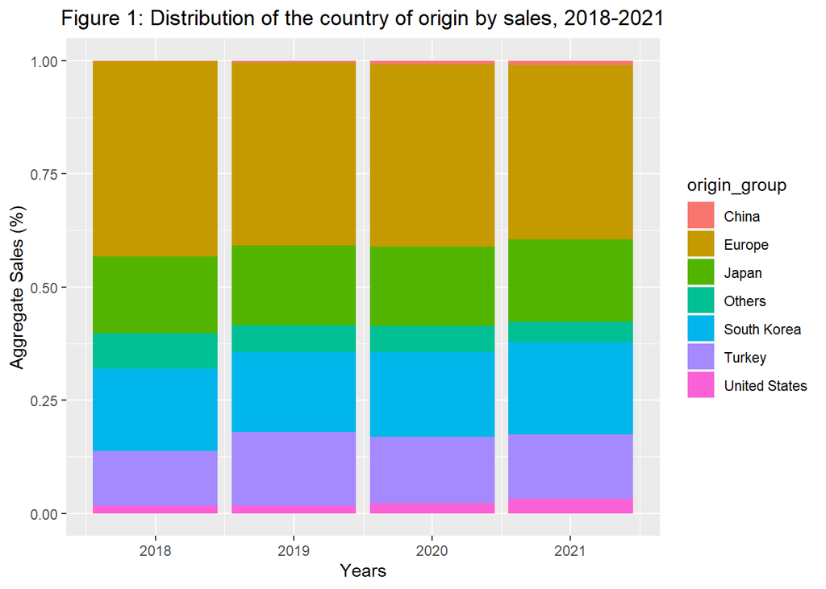

```r
# Auxiliary data frame of the old and new equilibrium data
mc_diff <- c(rep(0, 6788))
mc_diff[BLPdata$data$additional_data[,3] == "South Korea"] <-
  prices_pre[BLPdata$data$additional_data[,3] == "South Korea"] * 7/107

newdata <- tibble(
  Korea_ind = BLPdata$data$additional_data[,3] == "South Korea",
  market_id = BLPdata$parameters$market_id_char_in,
  product_id = BLPdata$parameters$product_id,
  prices_pre,
  prices_post,
  mc_pre = mc_pre_yevuan,
  mc_post = mc_pre - mc_diff,
  markups_pre = markups_yevuan,
  markups_post = prices_post - mc_post,
  original_shares = BLPdata$data$shares,
  shares_pre,
  shares_post,
  diff = shares_post - shares_pre    # Difference between old and new market shares
)


# Figure 1: Distribution of Country.of.Origin each - should we pick some aggregated brand variable instead?
europe <- unique(cars$Country.of.Origin)
europe <- europe[!europe %in% c("Thailand","Japan","South Korea","United States","China", "India","Mexico","Morocco","Canada","South Africa","Turkey")]
data_figure1 <- cars %>%
  select(year, Car.num, Country.of.Origin, Make.ENG) %>%
  filter(!is.na(Car.num))%>%
  mutate(
    origin_group = case_when(Country.of.Origin %in% europe ~ "Europe",
                             Country.of.Origin == "Turkey" ~ "Turkey",
                             Country.of.Origin == "United States" ~ "United States",
                             Country.of.Origin == "Japan" ~ "Japan",
                             Country.of.Origin == "China" ~ "China",
                             Country.of.Origin == "South Korea" ~ "South Korea",
                             TRUE ~ "Others")
  ) %>%
  group_by(year, origin_group) %>%
  summarise(sales = sum(Car.num)) %>%
  ungroup()

(figure1 <- ggplot(data_figure1, aes(x = year, y = sales, fill = origin_group)) +
    geom_bar(position = "fill", stat = "identity") +
    xlab("Years") +
    ylab("Aggregate Sales (%)") +
    ggtitle("Figure 1: Distribution of the country of origin by sales, 2018-2021")) +
  theme(plot.title = element_text(hjust = 0.5))
```

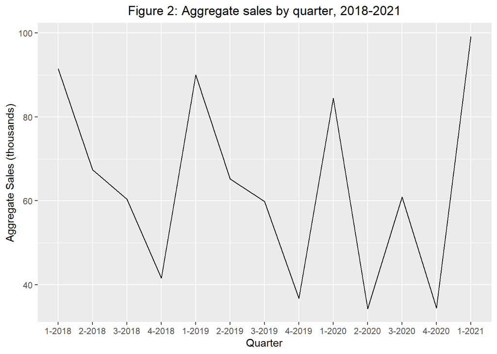

```r
# Figure 2: Graph of aggregate sales per market_id
data_figure2 <- cars[order(cars$market_id),]
data_figure2 <- data_figure2 %>%
  select(market_id,Car.num,year,quarter) %>%
  mutate(Quarter = paste(quarter,year, sep="-")) %>%
  filter(!is.na(Car.num))%>%
  group_by(market_id,Quarter)%>%
  summarise(sales=sum(Car.num)) %>%
  ungroup()

(figure2 <- ggplot(data_figure2, aes(x = fct_reorder(Quarter, market_id, .desc = FALSE), y = sales / 1000, group = 1)) +
  geom_line() +
  xlab("Quarter") +
  ylab("Aggregate Sales (thousands)") +
  ggtitle("Figure 2: Aggregate sales by quarter, 2018-2021")) +
  theme(plot.title = element_text(hjust = 0.5))
```

```r
# Table 1: Summary statistics of variables of interest
table1 <- productData %>%
  select(sj, const_price, hp_weight, Kvutzat.Zihum, Nikud.Betihut, compet_num) %>%
  mutate(sj = sj * 100) %>%  # to express as percent
  sapply(summary) %>%
  as.matrix()
colnames(table1) <- c("Share (%)", "Price (2010 NIS)", "Horsepower/Weight", "Pollution Index", "Safety Index", "Models in segment")

table1 %>% kable_format(digits = c(4, 3, 3, 1, 1, 1))
```

|  | Share (%) | Price (2010 NIS) | Horsepower/Weight | Pollution Index | Safety Index | Models in segment |
| --- | --- | --- | --- | --- | --- | --- |
| Min. | 0.0002 | 55.840 | 0.044 | 1.0 | 0.5 | 2.0 |
| 1st Qu. | 0.0004 | 124.704 | 0.065 | 7.0 | 3.5 | 189.0 |
| Median | 0.0008 | 152.537 | 0.075 | 11.0 | 6.0 | 352.0 |
| Mean | 0.0024 | 188.003 | 0.078 | 10.1 | 5.3 | 353.9 |
| 3rd Qu. | 0.0022 | 220.415 | 0.085 | 14.0 | 7.5 | 510.0 |
| Max. | 0.0931 | 741.114 | 0.200 | 15.0 | 10.5 | 829.0 |

```r
# Table 2: Regression Outputs – simple logit 1st and 2nd stages
firststage <- logit_model$iv_first_stage$const_price$coeftable[2:11,1:3]
rownames(firststage) <- c("ExchangeRate","ExchangeRate^2","CustomsDuty",
                          "Number of Competitors","Competitors' Safety Index",
                          "Competitors' HP","ExchangeRate*CustomsDuty",
                          "ExchangeRate*compet_safety","ExchangeRate*compet_num",
                          "ExchangeRate*compet_hp")
colnames(firststage) <- c("Coef.","Std. Error","T-value")
firststage %>% kable_format(digits = c(1, 1, 1),caption = "First Stage (Instruments Only)")
```

First Stage (Instruments Only)

|  | Coef. | Std. Error | T-value |
| --- | --- | --- | --- |
| ExchangeRate | -945.1 | 61.5 | -15.4 |
| ExchangeRate^2 | 109.8 | 7.4 | 14.9 |
| CustomsDuty | -6640.9 | 656.4 | -10.1 |
| Number of Competitors | 0.1 | 0.0 | 3.0 |
| Competitors’ Safety Index | -29.0 | 5.1 | -5.6 |
| Competitors’ HP | 0.4 | 0.4 | 1.1 |
| ExchangeRate*CustomsDuty | 1719.3 | 186.7 | 9.2 |
| ExchangeRate*compet_safety | 8.3 | 1.3 | 6.6 |
| ExchangeRate*compet_num | 0.0 | 0.0 | -3.1 |
| ExchangeRate*compet_hp | -0.1 | 0.1 | -0.9 |

```r
secondstage <- logit_model$coeftable[c(1:7, length(logit_model$coefficients)),1:3]
rownames(secondstage) <- c("Intercept","Price","HP/weight","Pollution Index",
                           "Safety Index","Less than 5 seats","More than 5 seats", "Time-trend")
colnames(secondstage) <- c("Coef.","Std. Error","T-value")
secondstage %>% kable_format(digits = c(3, 3, 1),caption = "Second Stage")
```

Second Stage

|  | Coef. | Std. Error | T-value |
| --- | --- | --- | --- |
| Intercept | -9.758 | 0.289 | -33.7 |
| Price | -0.001 | 0.001 | -0.7 |
| HP/weight | -7.801 | 1.921 | -4.1 |
| Pollution Index | -0.050 | 0.007 | -7.3 |
| Safety Index | 0.015 | 0.007 | 2.0 |
| Less than 5 seats | -0.562 | 0.102 | -5.5 |
| More than 5 seats | -0.270 | 0.079 | -3.4 |
| Time-trend | -0.025 | 0.004 | -6.9 |

```r
# Table 3: RCL results
linear <- cbind(BLP$theta_lin[c(1:7, length(BLP$theta_lin)), 1], BLP$se_linear[c(1:7, length(BLP$se_linear))], BLP$theta_lin[c(1:7, length(BLP$theta_lin)), 1] / BLP$se_linear[c(1:7, length(BLP$se_linear))])
rownames(linear) <- c("Intercept","Price","HP/weight","Pollution Index",
                      "Safety Index","Less than 5 seats","More than 5 seats",
                      "Time-trend")
colnames(linear) <- c("Coef.","Std. Error","T-value")
linear %>% kable_format(digits = c(3, 3, 2),caption = "Linear Coefficients")
```

Linear Coefficients

|  | Coef. | Std. Error | T-value |
| --- | --- | --- | --- |
| Intercept | -8.538 | 1.811 | -4.71 |
| Price | -0.026 | 0.010 | -2.62 |
| HP/weight | 0.703 | 3.074 | 0.23 |
| Pollution Index | -0.023 | 0.104 | -0.23 |
| Safety Index | 0.034 | 0.010 | 3.33 |
| Less than 5 seats | -0.858 | 0.105 | -8.14 |
| More than 5 seats | 0.167 | 0.645 | 0.26 |
| Time-trend | -0.027 | 0.017 | -1.60 |

```r
rc <- cbind(BLP$theta_rc,BLP$se_rc,BLP$theta_rc/BLP$se_rc)
rownames(rc) <- c("Intercept","Price","Pollution Index","More than 5 seats")
colnames(rc) <- c("Coef.","Std. Error","T-value")
rc %>% kable_format(digits = c(3, 3, 2),caption = "Random Coefficients")
```

Random Coefficients

|  | Coef. | Std. Error | T-value |
| --- | --- | --- | --- |
| Intercept | -1.521 | 1.059 | -1.44 |
| Price | -0.010 | 0.003 | -3.39 |
| Pollution Index | -0.057 | 0.102 | -0.56 |
| More than 5 seats | 0.239 | 3.080 | 0.08 |

```r
# Table 4: Elasticities
table_elasticities <- elasticities_i[c("9001","10173","10245","10133","9962","9938","10178"), c("9001","10173","10245","10133","9962","9938","10178")]
rownames(table_elasticities) <- c("Hyundai Ioniq Hybrid", "Hyundai i20", "Kia Picanto", "Toyota Corolla HSD SDN", "Seat Arona", "Renault Megane", "Hyundai i10")
colnames(table_elasticities) <- c("Hyundai Ioniq Hybrid", "Hyundai i20", "Kia Picanto", "Toyota Corolla HSD SDN", "Seat Arona", "Renault Megane", "Hyundai i10")

table_elasticities %>% kable_format()
```

|  | Hyundai Ioniq Hybrid | Hyundai i20 | Kia Picanto | Toyota Corolla HSD SDN | Seat Arona | Renault Megane | Hyundai i10 |
| --- | --- | --- | --- | --- | --- | --- | --- |
| Hyundai Ioniq Hybrid | -2.8 | 0.0 | 0.0 | 0.0 | 0.0 | 0.0 | 0.0 |
| Hyundai i20 | 0.0 | -2.1 | 0.0 | 0.0 | 0.0 | 0.0 | 0.0 |
| Kia Picanto | 0.0 | 0.0 | -1.9 | 0.0 | 0.0 | 0.0 | 0.0 |
| Toyota Corolla HSD SDN | 0.0 | 0.0 | 0.0 | -2.8 | 0.0 | 0.0 | 0.0 |
| Seat Arona | 0.0 | 0.0 | 0.0 | 0.0 | -2.4 | 0.0 | 0.0 |
| Renault Megane | 0.0 | 0.0 | 0.0 | 0.0 | 0.0 | -2.8 | 0.0 |
| Hyundai i10 | 0.0 | 0.0 | 0.0 | 0.0 | 0.0 | 0.0 | -1.9 |

```r
# Table 5: Prices, MCs, markups, for the 7 models
table_mc_markup <- as.matrix(newdata %>% filter(product_id %in% c(9001,10173,10245,10133,9962,9938,10178)) %>%                         select(prices_pre,mc_pre,markups_pre,prices_post,mc_post,markups_post) %>%
                             mutate(ms_pre = markups_pre/prices_pre,
                                    ms_post = markups_post/prices_post,
                                    change_price = 100 * (prices_post/prices_pre -1)))
rownames(table_mc_markup) <- c("Hyundai Ioniq Hybrid","Hyundai i20","Kia Picanto","Toyota Corolla HSD SDN","Seat Arona","Renault Megane","Hyundai i10")
colnames(table_mc_markup) <- c("Price", "MC", "Markup", "FTA Price", "FTA MC", "FTA Markup", "Markup/ Price", "FTA Markup/ Price", "% Change in Price")

table_mc_markup %>% kable_format(digits = c(0, 0, 0, 0, 0, 0, 2, 2, 2))
```

[output not shown]

```r
# Table 6: Aggregate market changes for Korean and non-Korean cars
table6 <- newdata %>%
  group_by(Korea_ind) %>%
  summarise(
    mean_price_change = mean(100 * (prices_post / prices_pre - 1)),
    sd_prices_change = sd(100 * (prices_post / prices_pre - 1)),
    mean_mc_change = mean(100 * (mc_post / mc_pre - 1)),
    sd_mc_change = sd(100 * (mc_post / mc_pre - 1)),
    mean_markup_change = mean(100 * (markups_post / markups_pre - 1)),
    sd_markup_change = sd(100 * (markups_post / markups_pre - 1)),
    mean_share_change = mean(100 * (shares_post / shares_pre - 1)),
    sd_share_change = sd(100 * (shares_post / shares_pre - 1))
  ) %>%
  t()
table6_overallcolumn <- newdata %>%
    summarise(
        mean_price_change = mean(100 * (prices_post / prices_pre - 1)),
        sd_prices_change = sd(100 * (prices_post / prices_pre - 1)),
        mean_mc_change = mean(100 * (mc_post / mc_pre - 1)),
        sd_mc_change = sd(100 * (mc_post / mc_pre - 1)),
        mean_markup_change = mean(100 * (markups_post / markups_pre - 1)),
        sd_markup_change = sd(100 * (markups_post / markups_pre - 1)),
        mean_share_change = mean(100 * (shares_post / shares_pre - 1)),
        sd_share_change = sd(100 * (shares_post / shares_pre - 1))
    ) %>%
    t()
```